# IODS course project

Fit a linear mixed random slope and intercept model with interaction between time and treatment.

```r
bprs_ref3 <- lmer(bprs ~ week * treatment + (week | subject), data = BPRSL, REML = FALSE)
summary(bprs_ref3)
```

```
## Linear mixed model fit by maximum likelihood . t-tests use Satterthwaite's
##   method [lmerModLmerTest]
## Formula: bprs ~ week * treatment + (week | subject)
##    Data: BPRSL
##
##      AIC      BIC   logLik deviance df.resid
##   2744.3   2775.4  -1364.1   2728.3      352
##
## Scaled residuals:
##     Min      1Q  Median      3Q     Max
## -3.0512 -0.6271 -0.0768  0.5288  3.9260
##
## Random effects:
##  Groups   Name        Variance Std.Dev. Corr
##  subject  (Intercept) 64.9964  8.0620
##           week         0.9687  0.9842   -0.51
##  Residual             96.4707  9.8220
## Number of obs: 360, groups:  subject, 20
##
## Fixed effects:
##                 Estimate Std. Error       df t value Pr(>|t|)
## (Intercept)      47.8856     2.2521  29.6312  21.262  < 2e-16 ***
## week             -2.6283     0.3589  41.7201  -7.323 5.24e-09 ***
## treatment2       -2.2911     1.9090 319.9977  -1.200   0.2310
## week:treatment2   0.7158     0.4010 319.9977   1.785   0.0752 .
## ---
## Signif. codes:  0 '***' 0.001 '**' 0.01 '*' 0.05 '.' 0.1 ' ' 1
##
## Correlation of Fixed Effects:
##             (Intr) week   trtmn2
## week        -0.650
## treatment2  -0.424  0.469
## wek:trtmnt2  0.356 -0.559 -0.840
```

Using lmertest package to get p values for the effects. It seems that the scores diminish as function of time (week) with a highly significant effect (p<0.001). Treatment does not affect scores, whereas time and treatment have trending interaction effect (p=0.08).

```r
anova(bprs_ref3, bprs_ref2)
```

```
## Data: BPRSL
## Models:
## bprs_ref2: bprs ~ week + treatment + (week | subject)
## bprs_ref3: bprs ~ week * treatment + (week | subject)
##           npar    AIC    BIC  logLik deviance  Chisq Df Pr(>Chisq)
## bprs_ref2    7 2745.4 2772.6 -1365.7   2731.4
## bprs_ref3    8 2744.3 2775.4 -1364.1   2728.3 3.1712  1    0.07495 .
## ---
## Signif. codes:  0 '***' 0.001 '**' 0.01 '*' 0.05 '.' 0.1 ' ' 1
```

Does not improve the fit significantly (p=0.08), but is an improvement still.

Plot the observed and fitted values with some jitter for readability.

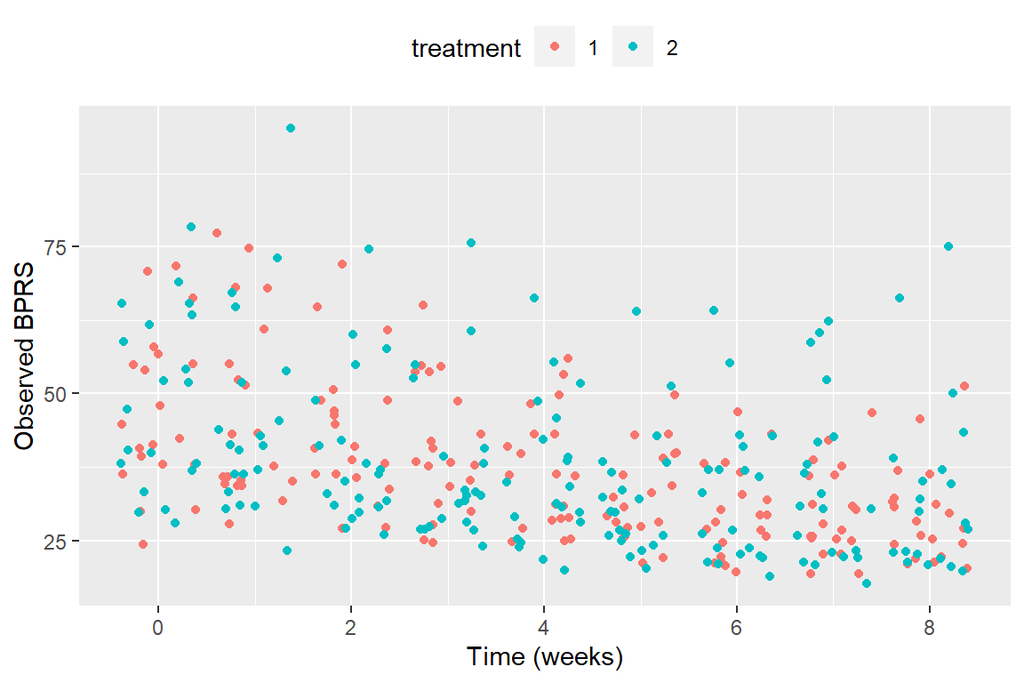

```r
BPRSL$fitted <- fitted(bprs_ref3)

ggplot(BPRSL, aes(x = week, y = bprs, group = subject)) +
  geom_jitter(aes(color = treatment)) +
  scale_x_continuous(name = "Time (weeks)", breaks = seq(0, 8, 2)) +
  scale_y_continuous(name = "Observed BPRS") +
  theme(legend.position = "top")
```

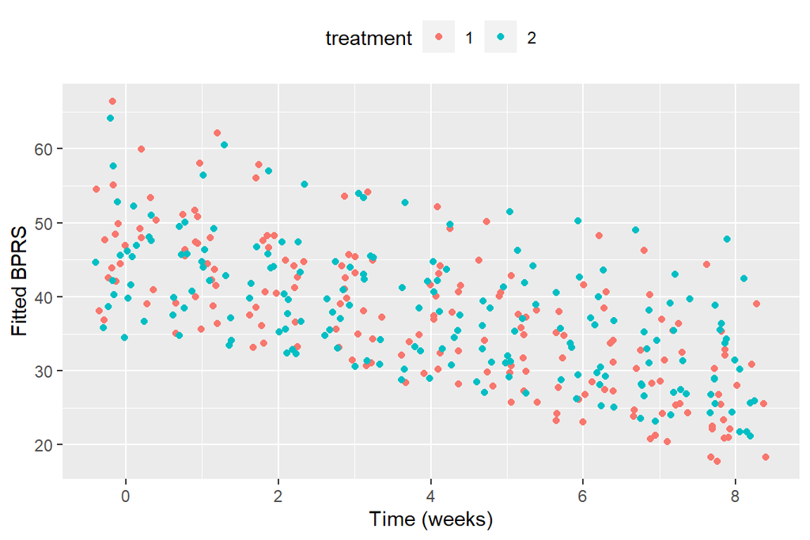

```r
ggplot(BPRSL, aes(x = week, y = fitted, group = subject)) +
  geom_jitter(aes(color = treatment)) +
  scale_x_continuous(name = "Time (weeks)", breaks = seq(0, 8, 2)) +
  scale_y_continuous(name = "Fitted BPRS") +
  theme(legend.position = "top")
```

It seems that the slope is slighty less negative for treatment group 2, as indicated by the trending interaction effect. Fit looks a bit aggressive, a lot of variation is unaccounted for. Main effect and it’s direction are clearly observable.

The effect of time would perhaps better be modelled as quadratic, as some participants’ scores, especially in group 2 ,seem to start rising at weeks 7 and 8.